# Dimensionality Reduction

## Dimensionality Reduction

### The Curse of Dimensionality

In real-world problems, it is often possible to reduce the number of fea‐ tures considerably, turning an intractable problem into a tractable one. For example, consider the MNIST images: the pixels on the image borders are almost always white, so you could completely drop these pixels from the training set without losing much information. Moreover, two neighboring pixels are often highly correlated: if you merge them into a single pixel (e.g., by taking the mean of the two pixel intensities), you will not lose much information.

> Reducing dimensionality does lose some information, so even though it will speed up training, it may also make your system per‐ form slightly worse. So you should first try to train your system with the original data before considering using dimen‐ sionality reduction if training is too slow. In some cases, however, reducing the dimensionality of the training data may filter out some noise and unnecessary details and thus result in higher per‐ formance.

> If you pick two points randomly in a unit square, the distance between these two points will be, on average, roughly 0.52. If you pick two random points in a unit 3D cube, the average distance will be roughly 0.66. But what about two points picked randomly in a 1,000,000-dimensional hypercube? Well, the average distance, will be about 408.25 (roughly $\sqrt{(1000000/6)}$.

This fact implies that highdimensional datasets are at risk of being very sparse: most training instances are likely to be far away from each other. Of course, this also means that a new instance will likely be far away from any training instance, making predictions much less relia‐ ble than in lower dimensions, since they will be based on much larger extrapolations. *In short, the more dimensions the training set has, the greater the risk of overfitting it.*

In theory, one solution to the curse of dimensionality could be to increase the size of the training set to reach a sufficient density of training instances. Unfortunately, in practice, the number of training instances required to reach a given density grows exponentially with the number of dimensions. With just 100 features. you would need more training instances than atoms in the observable universe in order for training instances to be within 0.1 of each other on average, assuming they were spread out uniformly across all dimensions.

### Main Approaches for Dimensionality Reduction

#### Projection

In most real-world problems, training instances are not spread out uniformly across all dimensions. As a result, all training instances actually lie within (or close to) a much lower-dimensional subspace of the high-dimensional space.

#### A 3D dataset lying close to a 2D subspace

[figure not shown]

Notice that all training instances lie close to a plane: this is a lower-dimensional (2D) subspace of the high-dimensional (3D) space. Now if we project every training instance perpendicularly onto this subspace, we get the new 2D dataset.

#### The new 2D dataset after projection

[figure not shown]

However, projection is not always the best approach to dimensionality reduction. In many cases the subspace may twist and turn.

#### Manifold Learning

A 2D manifold is a 2D shape that can be bent and twisted in a higher-dimensional space. More generally, a d-dimensional manifold is a part of an n-dimensional space (where d < n) that locally resembles a d-dimensional hyperplane. In the case of the Swiss roll, d = 2 and n = 3: it locally resembles a 2D plane, but it is rolled in the third dimension.

#### Swiss roll dataset

[figure not shown]

> Many dimensionality reduction algorithms work by modeling the manifold on which the training instances lie; this is called *Manifold Learning*. It relies on the manifold assumption, also called the manifold hypothesis, which holds that most real-world high-dimensional datasets lie close to a much lower-dimensional manifold. This assumption is very often empirically observed.

The manifold assumption is often accompanied by another implicit assumption: that the task at hand (e.g., classification or regression) will be simpler if expressed in the lower-dimensional space of the manifold. However, this assumption is not always true.

> If you reduce the dimensionality of your training set before training a model, it will usually speed up training, but it may not always lead to a better or sim‐ pler solution; it all depends on the dataset.

#### The decision boundary may not always be simpler with lower dimensions

[figure not shown]

### PCA

*Principal Component Analysis (PCA)* is by far the most popular dimensionality reduc‐ tion algorithm. First it identifies the hyperplane that lies closest to the data, and then it projects the data onto it.

#### Preserving the Variance

Before you can project the training set onto a lower-dimensional hyperplane, you first need to choose the right hyperplane. As you can see, the projection onto the solid line preserves the maximum variance, while the projection onto the dotted line preserves very little variance, and the projection onto the dashed line preserves an intermediate amount of variance.

#### Selecting the subspace onto which to project

[figure not shown]

> It seems reasonable to select the axis that preserves the maximum amount of var‐ iance, as it will most likely lose less information than the other projections. Another way to justify this choice is that it is the axis that minimizes the mean squared dis‐ tance between the original dataset and its projection onto that axis. This is the rather simple idea behind PCA.

#### Principal Components

PCA identifies the axis that accounts for the largest amount of variance in the train‐ ing set. It also finds a second axis, orthogonal to the first one, that accounts for the largest amount of remaining variance. In this 2D example there is no choice: it is the dotted line. If it were a higher-dimensional data‐ set, PCA would also find a third axis, orthogonal to both previous axes, and a fourth, a fifth, and so on—as many axes as the number of dimensions in the dataset. For the above figure, **C1** and **C2** are the two principal components.

> The direction of the principal components is not stable: if you per‐ turb the training set slightly and run PCA again, some of the new PCs may point in the opposite direction of the original PCs. How‐ ever, they will generally still lie on the same axes. In some cases, a pair of PCs may even rotate or swap, but the plane they define will generally remain the same.

To find the principal components, there is a standard matrix factorization technique called Singular Value Decomposition (SVD) that can decompose the training set matrix X into the matrix multiplication of three matrices $U Σ V^T$, where V contains all the principal components that we are looking for. The following Python code uses NumPy’s svd() function to obtain all the principal components of the training set, then extracts the first two PCs:

```python
import numpy as np
from sklearn.datasets import load_iris
iris = load_iris()
X = iris.data
X_centered = X - X.mean(axis=0)
U, s, Vt = np.linalg.svd(X_centered)
c1 = Vt.T[:, 0]
c2 = Vt.T[:, 1]
```

```python
c1, c2
```

```
(array([ 0.36138659, -0.08452251,  0.85667061,  0.3582892 ]),
 array([-0.65658877, -0.73016143,  0.17337266,  0.07548102]))
```

#### Projecting Down to d Dimensions

Once you have identified all the principal components, you can reduce the dimen‐ sionality of the dataset down to d dimensions by projecting it onto the hyperplane defined by the first d principal components.

To project the training set onto the hyperplane, you can simply compute the matrix multiplication of the training set matrix $\mathbf{X}$ by the matrix $\mathbf{W_d}$, defined as the matrix containing the first d principal components (i.e., the matrix composed of the first d columns of **V**) $$\mathbf{X} = \mathbf{X}\mathbf{W_d} $$

```python
W2 = Vt.T[:, :2]
X2D = X_centered.dot(W2)
```

```python
# X2D
```

#### Using Scikit-Learn

Scikit-Learn’s PCA class implements PCA using SVD decomposition just like we did before.

```python
from sklearn.decomposition import PCA
pca = PCA(n_components = 2)
X2D = pca.fit_transform(X)
```

```python
pca.components_, c1, c2
```

```
(array([[ 0.36138659, -0.08452251,  0.85667061,  0.3582892 ],
        [ 0.65658877,  0.73016143, -0.17337266, -0.07548102]]),
 array([ 0.36138659, -0.08452251,  0.85667061,  0.3582892 ]),
 array([-0.65658877, -0.73016143,  0.17337266,  0.07548102]))
```

We get the same results.

> Another very useful piece of information is the explained variance ratio of each prin‐ cipal component, available via the `explained_variance_ratio_ variable`. It indicates the proportion of the dataset’s variance that lies along the axis of each principal com‐ ponent.

```python
pca.explained_variance_ratio_
```

```
array([0.92461872, 0.05306648])
```

```python
pca.explained_variance_ratio_.sum()
```

```
0.977685206318795
```

We see that the first two principal components explain most of the variance (97.8%). Only about 2.2% of the variance lies along the third and the fourth principal component.

#### Choosing the Right Number of Dimensions

Instead of arbitrarily choosing the number of dimensions to reduce down to, it is generally preferable to choose the number of dimensions that add up to a sufficiently large portion of the variance (e.g., 95%). Unless, of course, you are reducing dimen‐ sionality for data visualization—in that case you will generally want to reduce the dimensionality down to 2 or 3.

```python
pca = PCA()
pca.fit(X)
cumsum = np.cumsum(pca.explained_variance_ratio_)
d = np.argmax(cumsum >= 0.95) + 1
d
```

```
2
```

```python
pca = PCA(n_components=0.95)
X_reduced = pca.fit_transform(X)
```

#### PCA for Compression

```python
from sklearn.datasets import load_digits
digits = load_digits()
X_mn = digits.data
```

Let's apply PCA on the 64 dimensional mnist dataset.

```python
pca = PCA(n_components=0.95)
X_reduced_mn = pca.fit_transform(X_mn)
```

```python
X_mn.shape, X_reduced_mn.shape
```

```
((1797, 64), (1797, 29))
```

The number of features decreases from 64 to 29!

> It is also possible to decompress the reduced dataset back to the original 64-dimensions. This can be done using the `inverse_transform` method. It won't return the original dataset, since 5% of information is lost. However, it will be VERY close to the original dataset.

```python
pca = PCA(n_components = 64)
X_reduced = pca.fit_transform(X_mn)
X_recovered = pca.inverse_transform(X_reduced)
```

```python
np.abs((X_recovered- X_mn)).sum()
```

```
1.0728413330118845e-09
```

You can see, the `X_recovered` and `X_mn` are the same. The sum of there absolute differences is 1 in a billion part!

$$\mathbf{X_{rec}} = \mathbf{X_{d}}\mathbf{W}^T$$

> If you set the `svd_solver` hyperparameter to `"randomized"`, Scikit-Learn uses a sto‐ chastic algorithm called Randomized PCA that quickly finds an approximation of the first d principal components. Its computational complexity is $O(m × d^2) + O(d^3)$, where $m$ is the number of training samples and $d$ is the number of dimensions., instead of $O(m × n^2) + O(n^3)$ for the full SVD approach, so it is dramatically faster than full SVD when d is much smaller than n:

Scikit-Learn automatically uses the randomized PCA algorithm if m or n is greater than 500 and d is less than 80% of m or n, or else it uses the full SVD approach. If you want to force Scikit-Learn to use full SVD, you can set the `svd_solver` hyperparameter to `"full"`.

#### Incremental PCA

One problem with the preceding implementations of PCA is that they require the whole training set to fit in memory in order for the algorithm to run. Fortunately, Incremental PCA (IPCA) algorithms have been developed: you can split the training set into mini-batches and feed an IPCA algorithm one mini-batch at a time.

```python
from sklearn.decomposition import IncrementalPCA
n_batches = 100
inc_pca = IncrementalPCA(n_components=17)
for X_batch in np.array_split(X_mn, n_batches):
    inc_pca.partial_fit(X_batch)
X_reduced = inc_pca.transform(X_mn)
```

```python
X_reduced.shape
```

```
(1797, 17)
```

Alternatively, you can use NumPy’s `memmap` class, which allows you to manipulate a large array stored in a binary file on disk as if it were entirely in memory; the class loads only the data it needs in memory, when it needs it. Since the `IncrementalPCA` class uses only a small part of the array at any given time, the memory usage remains under control. This makes it possible to call the usual `fit()` method

```python
X_mm = np.memmap(filename, dtype="float32", mode="readonly", shape=(m, n))
batch_size = m // n_batches
inc_pca = IncrementalPCA(n_components=154, batch_size=batch_size)
inc_pca.fit(X_mm)
```

### Kernel PCA

The *Kernel trick* can also be applied to PCA, making it possible to perform complex nonlinear projections for dimensionality reduction. For example, the following code uses Scikit-Learn’s `KernelPCA` class to perform `kPCA` with an `RBF` kernel.

```python
from sklearn.decomposition import KernelPCA
import matplotlib.pyplot as plt
rbf_pca = KernelPCA(n_components = 2, kernel="rbf", gamma=0.04)
X_reduced = rbf_pca.fit_transform(X)
```

```python
from sklearn.datasets import make_swiss_roll
X, t = make_swiss_roll(n_samples=1000, noise=0.2, random_state=42)
```

```python
def plot_pca_scatter(X, kernel):
    rbf_pca = KernelPCA(n_components = 2, kernel=kernel, gamma=0.04)
    X_reduced = rbf_pca.fit_transform(X)
    plt.figure(figsize=(8, 6))
    plt.scatter(X_reduced[:, 0], X_reduced[:, 1], c=X_reduced[:, 0], cmap="viridis")
    plt.title("Kernel PCA with kernel = {}".format(kernel))
```

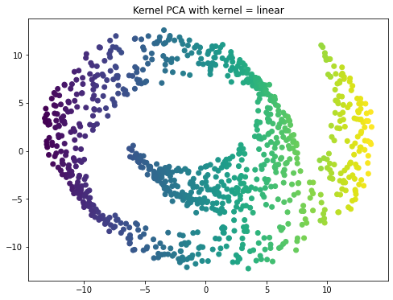

```python
axes = plot_pca_scatter(X, "linear")
```

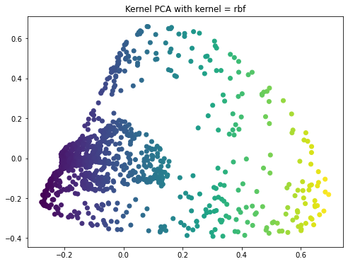

```python
plot_pca_scatter(X, "rbf")
```

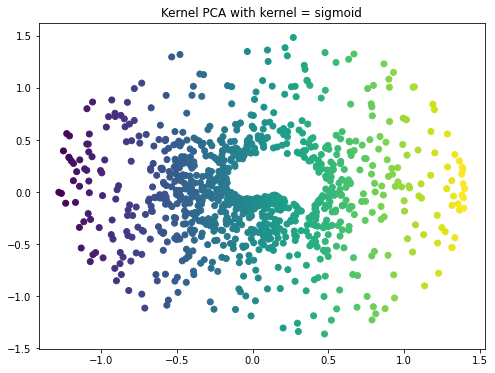

```python
plot_pca_scatter(X, "sigmoid")
```

The above figures shows the Swiss roll, reduced to two dimensions using a linear kernel (equivalent to simply using the PCA class), an RBF kernel, and a sigmoid kernel (Logistic)

#### Selecting a Kernel and Tuning Hyperparameters

You can simply use grid search to select the kernel and hyperparameters that lead to the best performance.

```python
from sklearn.model_selection import GridSearchCV
from sklearn.linear_model import LogisticRegression
from sklearn.pipeline import Pipeline

clf = Pipeline([("kpca", KernelPCA(n_components=2)), ("log_reg", LogisticRegression())])

param_grid = [
    {"kpca__gamma": np.linspace(0.03, 0.05, 10), "kpca__kernel": ["rbf", "sigmoid"]}
]

grid_search = GridSearchCV(clf, param_grid, cv=3)
grid_search.fit(X, t)
```

### Other Dimensionality Reduction Techniques

#### LLE

*Locally Linear Embedding* (LLE) is another very powerful nonlinear dimensionality reduction (NLDR) technique. It is a Manifold Learning technique that does not rely on projections like the previous algorithms. In a nutshell, LLE works by first measur‐ ing how each training instance linearly relates to its closest neighbors (c.n.), and then looking for a low-dimensional representation of the training set where these local relationships are best preserved.  
For example, the following code uses Scikit-Learn’s `LocallyLinearEmbedding` class to unroll the Swiss roll.

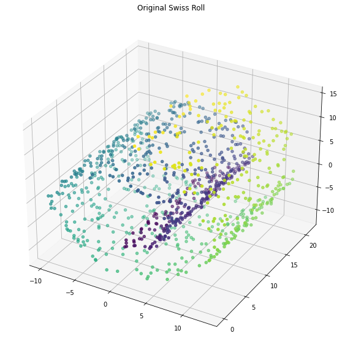

```python
fig = plt.figure(figsize=(12,10))
ax =plt.axes(projection ='3d')
ax.scatter3D(X[:, 0], X[:, 1], X[:, 2], c=t, cmap="viridis")
ax.set_title("Original Swiss Roll");
```

```python
from sklearn.manifold import LocallyLinearEmbedding
lle = LocallyLinearEmbedding(n_components=2, n_neighbors=10)
X_reduced = lle.fit_transform(X)
```

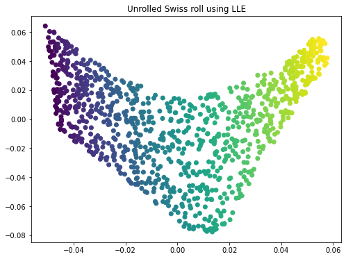

```python
plt.figure(figsize=(8, 6))
plt.scatter(X_reduced[:, 0], X_reduced[:, 1], cmap="viridis", c=t)
plt.title("Unrolled Swiss roll using LLE");
```

There are many other dimensionality reduction techniques, several of which are available in Scikit-Learn. Here are some of the most popular:

- **Multidimensional Scaling (MDS)** reduces dimensionality while trying to preserve the distances between the instances.
- **Isomap** creates a graph by connecting each instance to its nearest neighbors, then reduces dimensionality while trying to preserve the geodesic distances9 between the instances.
- **t-Distributed Stochastic Neighbor Embedding (t-SNE)** reduces dimensionality while trying to keep similar instances close and dissimilar instances apart. It is mostly used for visualization, in particular to visualize clusters of instances in high-dimensional space (e.g., to visualize the MNIST images in 2D).
- **Linear Discriminant Analysis (LDA)** is actually a classification algorithm, but dur‐ ing training it learns the most discriminative axes between the classes, and these axes can then be used to define a hyperplane onto which to project the data. The benefit is that the projection will keep classes as far apart as possible, so LDA is a good technique to reduce dimensionality before running another classification algorithm such as an SVM classifier.

#### Reducing the Swiss roll to 2D using various techniques

[figure not shown]